# Intro to TaD

Author

Affiliation

Carolina Torreblanca

University of Pennsylvania

Published

May 23, 2025

## Text as Data

- Text contains information about the process that produced it
  - Ideology of writer, intent, sentiment, topic
- These facets are what we care about but we cannot directly observe them
  - Latent characteristics
- We want to make inferences about these characteristics with the text they produced

## From text to numbers in a nutshell

1. Get documents
2. Preprocess: Remove everything we don’t need (hyperlinks, punctuation, stopwords)
3. Split into words (or tokens)
4. Create a document-term matrix

## Terminology

- **type:** unique sequence of characters with some meaning
  - usually a word. i.e: Cat, 1984
- **token:** appearances of a type
  - i.e: “Babies having babies” contains three tokens but two types
  - usually separated by whitespace
- **term:** is a type after pre-processing
  - i.e: “revolutionary”, “revolution” both have the same term, “revoluti”

## Quanteda

- A very powerful package for text analysis. Not the only one! But the one we’ll use today
- Quanteda’s main objects are “corpus”: (text + metadata)
- We are going to use quanteda.corpora to get a bunch of text data
- We are going to use quanteda.textmodels to fit a text model

## Quanteda

```r
# install.packages(c("quanteda", "devtools", "quanteda.textmodels", "quanteda.corpora", "quanteda.textplots))
# or if that does not work:
# devtools::install_github("quanteda/quanteda.corpora")

require(quanteda)
require(quanteda.corpora)
require(quanteda.textplots)
require(quanteda.textmodels)
require(tidyverse)

# one of the pre-loaded datsaets on SOTU speeches
speeches <- (data_corpus_sotu)
summary(speeches, n = 10) # Corpus consists of 241 documents
```

```
Corpus consisting of 241 documents, showing 10 documents:

             Text Types Tokens Sentences FirstName  President       Date
  Washington-1790   460   1167        24    George Washington 1790-01-08
 Washington-1790b   591   1501        38    George Washington 1790-12-08
  Washington-1791   814   2471        58    George Washington 1791-10-25
  Washington-1792   769   2282        59    George Washington 1792-11-06
  Washington-1793   800   2116        54    George Washington 1793-12-03
  Washington-1794  1134   3192        77    George Washington 1794-11-19
  Washington-1795   819   2149        51    George Washington 1795-12-08
  Washington-1796  1003   3090        78    George Washington 1796-12-07
       Adams-1797   731   2230        59      John      Adams 1797-11-22
       Adams-1798   833   2368        58      John      Adams 1798-12-08
 delivery type       party
   spoken SOTU Independent
   spoken SOTU Independent
   spoken SOTU Independent
   spoken SOTU Independent
   spoken SOTU Independent
   spoken SOTU Independent
   spoken SOTU Independent
   spoken SOTU Independent
   spoken SOTU  Federalist
   spoken SOTU  Federalist
```

```r
# You can filter easily with dplyr-ish syntax
# We can use any of the variables in the metadata to filter
summary(corpus_subset(speeches, President == "Obama")) # 8 documents
```

```
Corpus consisting of 8 documents, showing 8 documents:

       Text Types Tokens Sentences FirstName President       Date delivery
 Obama-2009  1601   6701       286    Barack     Obama 2009-02-24   spoken
 Obama-2010  1818   7954       406    Barack     Obama 2010-01-27   spoken
 Obama-2011  1834   7647       403    Barack     Obama 2011-01-25   spoken
 Obama-2012  1894   7888       423    Barack     Obama 2012-01-24   spoken
 Obama-2013  1809   7354       350    Barack     Obama 2013-02-12   spoken
 Obama-2014  1927   7665       343    Barack     Obama 2014-01-28   spoken
 Obama-2015  1816   7549       374    Barack     Obama 2015-01-20   spoken
 Obama-2016  1720   6734       360    Barack     Obama 2016-01-12   spoken
  type      party
 other Democratic
  SOTU Democratic
  SOTU Democratic
  SOTU Democratic
  SOTU Democratic
  SOTU Democratic
  SOTU Democratic
  SOTU Democratic
```

```r
# lets create a new dataset with only obama speeches
obama_sotu <- corpus_subset(speeches, President == "Obama")

# you can get the text of each speech
as.character(obama_sotu)[1]
```

```
                                                                                                                                                                                                                                                                                                            …
"Madam Speaker, Mr. Vice President, Members of Congress, the First Lady of the United States-she's around here somewhere:\n\nI have come here tonight not only to address the distinguished men and women in this great Chamber, but to speak frankly and directly to the men and women who sent us here.\n\…
```

```r
# You can get the individual tokens of each speech
obama_tokens <- tokens(obama_sotu)
obama_tokens[[1]][1:20]
```

```
 [1] "Madam"        "Speaker"      ","            "Mr"           "."
 [6] "Vice"         "President"    ","            "Members"      "of"
[11] "Congress"     ","            "the"          "First"        "Lady"
[16] "of"           "the"          "United"       "States-she's" "around"
```

```r
# Notice some tokens are punctuation, others are not very informative

# lets try removing punctuation
obama_tokens <- tokens(obama_sotu, remove_punct = T)
obama_tokens[[1]][1:20]
```

```
 [1] "Madam"        "Speaker"      "Mr"           "Vice"         "President"
 [6] "Members"      "of"           "Congress"     "the"          "First"
[11] "Lady"         "of"           "the"          "United"       "States-she's"
[16] "around"       "here"         "somewhere"    "I"            "have"
```

```r
# better, but still, "Mr", "of" etc. not very informative
# these are stopwords - we will deal with them later
head(stopwords("english"), 15)
```

```
 [1] "i"          "me"         "my"         "myself"     "we"
 [6] "our"        "ours"       "ourselves"  "you"        "your"
[11] "yours"      "yourself"   "yourselves" "he"         "him"
```

## Technique 1: Key Words in Context

- One easy way to understand how words are used is to see what words are around them
- A good function for that is *kwic*

```r
(obama_kwic <- kwic(tokens(obama_sotu), pattern = "immigration", valuetype = "regex", window = 6))
```

```
Keyword-in-context with 13 matches.
 [Obama-2010, 7080]         the work of fixing our broken | immigration |
 [Obama-2011, 3304]             all, the issue of illegal | immigration |
 [Obama-2012, 2905]        that we should take on illegal | immigration |
 [Obama-2012, 2950] We should be working on comprehensive | immigration |
 [Obama-2013, 4049]   time has come to pass comprehensive | immigration |
 [Obama-2013, 4178]    real reform means fixing the legal | immigration |
 [Obama-2013, 4247]         done. Send me a comprehensive | immigration |
 [Obama-2014, 2371]      enforcement - and fix our broken | immigration |
 [Obama-2014, 2402]  the same. Independent economists say | immigration |
 [Obama-2014, 2469]            for everyone. So let's get | immigration |
 [Obama-2015, 1232]  Street or refighting past battles on | immigration |
 [Obama-2015, 6725]            Yes, passions still fly on | immigration |
  [Obama-2016, 244]              be done: fixing a broken | immigration |

 system - to secure our borders
 . I am prepared to work
 . That's why my administration has
 reform right now. But if
 reform. Now is the time
 system to cut waiting periods and
 reform bill in the next few
 system. Republicans and Democrats in
 reform will grow our economy and
 reform done this year. The
 when we've got to fix a
 , but surely we can all
 system, protecting our kids from
```

## Document Term Matrix

```r
obama_dfm <- dfm(obama_tokens)
head(obama_dfm)
```

```
Document-feature matrix of: 6 documents, 5,302 features (67.96% sparse) and 6 docvars.
            features
docs         madam speaker mr vice president members  of congress the first
  Obama-2009     1       1  1    2         5       1 161       10 269     8
  Obama-2010     0       1  0    2         6       2 166       10 326     6
  Obama-2011     0       2  0    0         1       1 196        9 349    11
  Obama-2012     0       2  2    2         5       3 170       15 294     8
  Obama-2013     0       1  2    1         2       1 164       17 288     5
  Obama-2014     0       2  2    2         5       2 153       20 277    14
[ reached max_nfeat ... 5,292 more features ]
```

```r
dim(obama_dfm)
```

```
[1]    8 5302
```

```r
# Too many columns! Lets see if removing stopwords can help

obama_dfm_2 <- dfm(obama_tokens, remove = stopwords("english"),
                       remove_punct = T)
dim(obama_dfm_2) # not bad
```

```
[1]    8 5138
```

```r
head(obama_dfm_2)
```

```
Document-feature matrix of: 6 documents, 5,138 features (69.56% sparse) and 6 docvars.
            features
docs         madam speaker mr vice president members congress first lady united
  Obama-2009     1       1  1    2         5       1       10     8    1      5
  Obama-2010     0       1  0    2         6       2       10     6    1      7
  Obama-2011     0       2  0    0         1       1        9    11    0      4
  Obama-2012     0       2  2    2         5       3       15     8    0      6
  Obama-2013     0       1  2    1         2       1       17     5    0      8
  Obama-2014     0       2  2    2         5       2       20    14    1      6
[ reached max_nfeat ... 5,128 more features ]
```

```r
# we can stem to improve it even more


obama_dfm_3 <- dfm(obama_tokens, remove = stopwords("english"),
                       stem =T,
                       remove_punct = T)
dim(obama_dfm_3) # MUCH MUCH better
```

```
[1]    8 3569
```

```r
head(obama_dfm_3)
```

[output not shown]

## Technique 2: Wordclouds

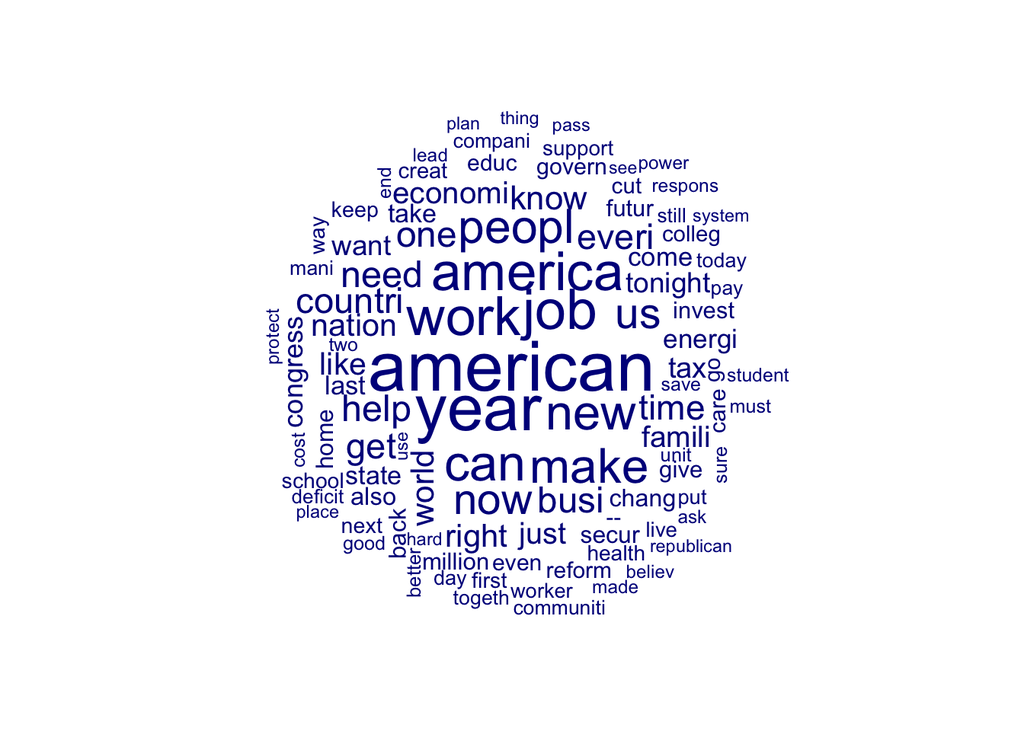

```r
# compare the one with stemming to
textplot_wordcloud(obama_dfm_3, max_words = 100)
```

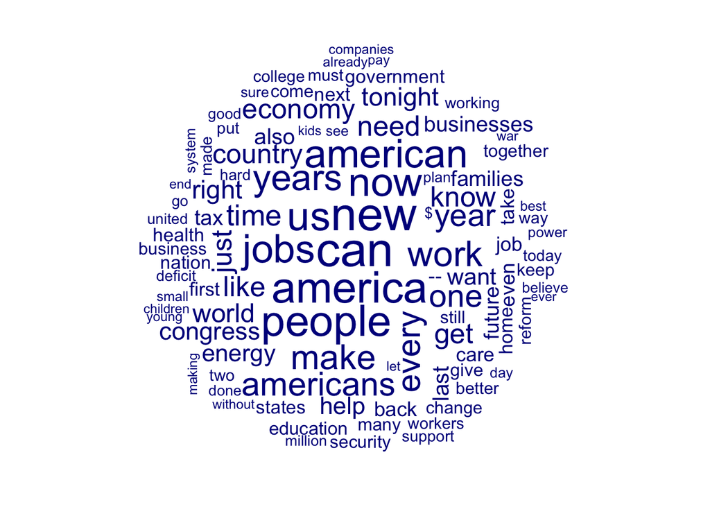

```r
# the one without
textplot_wordcloud(obama_dfm_2, max_words = 100)
```

## Technique 3: Supervised Learning with Dictionaries

A common way of making inferences about the data, in a supervised manner, is using a dictionary. Quanteda includes several dictionaries pre-loaded, but lets create our own and use it to infer sentiment in the speeches.

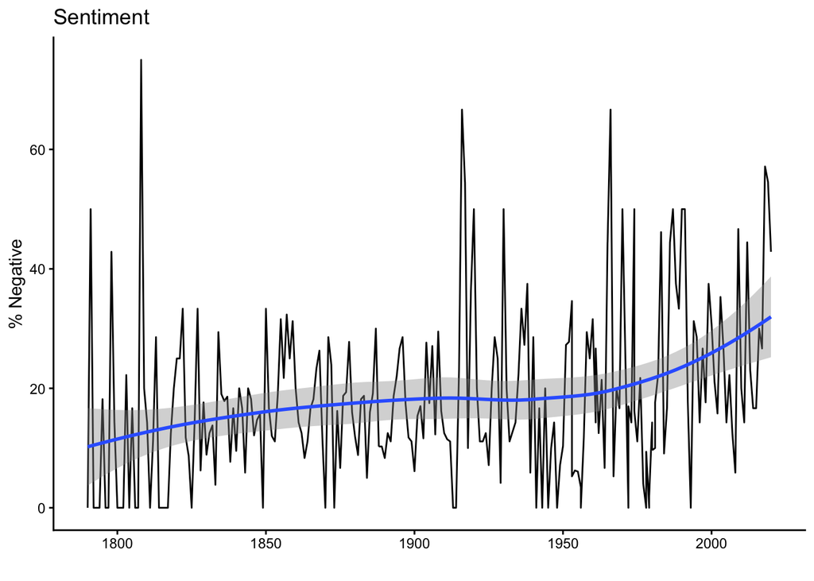

```r
out_dict <- dictionary(list(
  positive = c("good", "nice", "excellent", "positive", "fortunate",
                "successful", "effective", "efficient", "beneficial", "valuable", "useful",
               "advantageous", "productive", "profitable", "rewarding", "worthwhile",
               "correct", "superior", "happy", "bueno", "prosper"),
  negative = c("bad", "awful", "nasty", "negative", "unfortunate",
               "problematic", "concerning", "troubling", "worrisome", "alarming", "disturbing",
               "harmful", "damaging", "destructive", "ruinous", "catastrophic", "disastrous",
               "wrong", "inferior", "miserable", "terrible", "abusive")))

# Run the conservative manifestos through this dictionary
speeches_dic <- dfm_lookup(dfm(tokens(speeches)), dictionary = out_dict)

# Visualize this
sent_data_out <- convert(speeches_dic, to = "data.frame") %>%
  rowwise() %>%
  mutate(prop_negative = negative / sum(negative, positive) * 100,
         year = abs(parse_number(doc_id)))

ggplot(sent_data_out, aes(x = year, y = prop_negative)) +
  geom_line() +
  geom_smooth(method = "loess", formula = y ~ x) +
  labs(y = "% Negative", x = "", title= "Sentiment") +
  theme_classic()
```

## Technique 4: Unsupervised Topic Modeling

Quanteda also has a lot of built-in text models, including topic modeling. These models have deep theoretical foundations, but here we are just going to show a very hands-on application of a topic model. A popular one is LSA, or Latent Semantic Analysis. The idea is to identify “semantic dimensions”- or themes/ideas/concepts in documents.

```r
require(quanteda.textmodels)
# Lets take the entire corpus
speeches_dfm <- dfm(tokens(speeches), remove = stopwords("english"),
                    stem =T,
                    remove_punct = T)

# nd = number of semantic dimensions
# lets say 2: economics and social issues
# Note: it is unspurevised but WE have to make a substantive decision
# re the number of semantic dimensions there are
lsa_model <- textmodel_lsa(speeches_dfm, nd = 2)

# you can seee, each doc is assigned a score for 2 dimension
head(lsa_model$docs)
```

```
                        [,1]        [,2]
Washington-1790  0.006154892 0.005352405
Washington-1790b 0.007043385 0.005295575
Washington-1791  0.013496442 0.014350353
Washington-1792  0.010954959 0.009935531
Washington-1793  0.012479789 0.012618771
Washington-1794  0.014478341 0.014691720
```

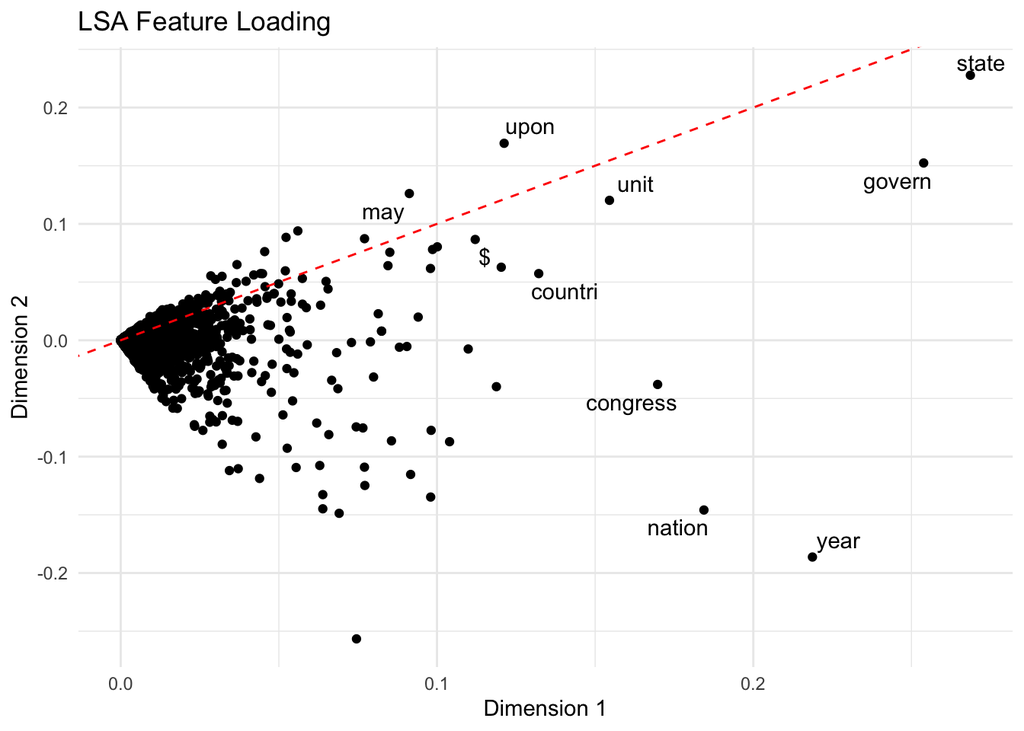

```r
# lets see what words load onto the dimensions
features <- data.frame(feature = rownames(lsa_model$features),
                       dim1 = lsa_model$features[,1],
                       dim2 = lsa_model$features[,2])

pacman::p_load(ggrepel)

ggplot(features, aes(x = dim1, y = dim2)) +
  geom_point() +
  geom_text_repel(data = filter(features, dim1 > .12 | dim2 >.12),
  aes(label = feature)) +
    geom_abline(slope = 1, intercept = 0,
                linetype = "dashed", color = "red") +
  theme_minimal() +
  labs(x = "Dimension 1", y = "Dimension 2",
       title = "LSA Feature Loading")
```

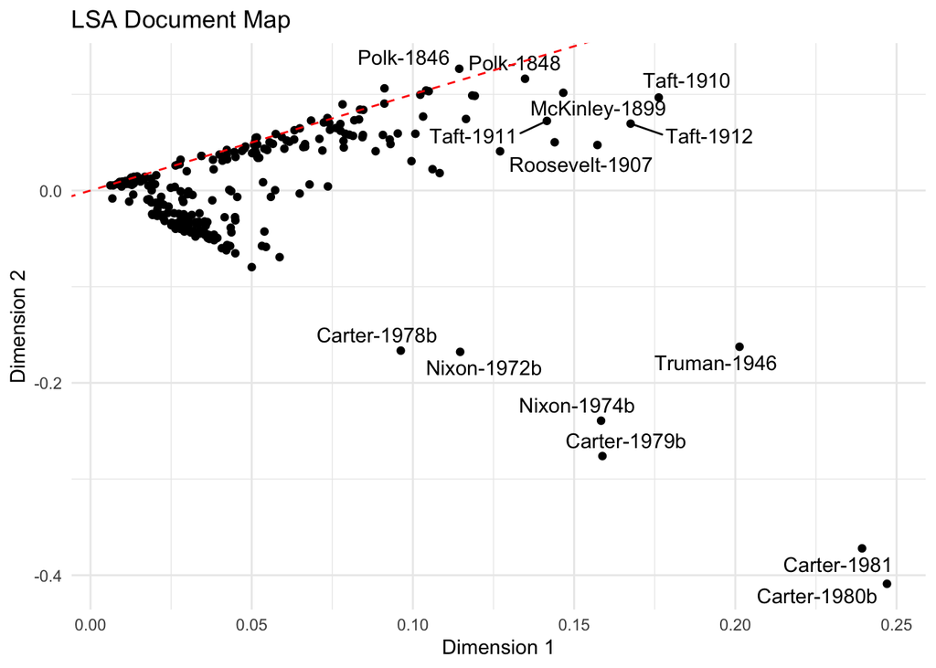

```r
# we can visualize it
docs <- data.frame(doc = rownames(lsa_model$docs),
                       dim1 = lsa_model$docs[,1],
                       dim2 = lsa_model$docs[,2])

# Create plot with ggplot2
ggplot(docs, aes(x = dim1, y = dim2, label = doc)) +
  geom_point() +
  geom_text_repel() +
  theme_minimal() +
      geom_abline(slope = 1, intercept = 0,
                linetype = "dashed", color = "red") +
  labs(x = "Dimension 1", y = "Dimension 2",
       title = "LSA Document Map")
```

```r
# 2 semantic dimensions is probably not great!
```